# SQMF - Summative Assessment

B214220

2023-01-16

# Instructions

**PLEASE READ CAREFULLY**

**IMPORTANT**: Remember to include your exam number as the author in the document preamble above.

**DUE THURSDAY 8 DECEMBER AT NOON**

**You must submit both to GitHub and to Learn**. No exceptions will be made.

The assessment is made of two parts:

- **Part I** is a series of semi-guided exercises on topics and procedures covered in class.
- **Part II** requires you to run a full data analysis of a data set from a set of four. You will have to pick one of the four data sets.

Complete each exercise by completing tasks, answering questions and/or providing code if required. You will have to download the data for this assessment and copy it into the `data/` folder. A link to download the data will be provided via an announcement.

When you are ready to submit:

1. Render the Rmd file to HTML.
2. Upload the Rmd and HTML file and the data files to GitHub. They should be uploaded in the correct folder (`code/` and `data/`).
3. Create a confirmation file to upload to Learn. **The file must be named with your exam number only**: for example, `B231789.txt`, `B098273.docx`. **Failure to upload the file or not naming the file appropriately will correspond to a fail.**

# Part I

Part I consists of a set of semi-guided exercises that assess your understanding of statistical concepts and R code.

There are a total of 9 exercises.

## Excercise 1

You are given three data files and you have to create one plot for each. Each data file requires you to read in the file, filter/transform the data and create a plot that shows a particular aspect of the data, as follows:

1. `data_e1_1.csv`: Plot centred speech rate against f0 at vowel mid-point, by condition and group, faceting by vowel.
2. `data_e1_2.csv`: Plot logged reaction times by language, environment, and age.
3. `data_e1_3.csv`: Plot proportions of incorrect vs correct responses across trial number in the easy and difficult condition, faceting by priming setting.

```r
data_e1_1 <- read_csv("data/data_e1_1.csv")
```

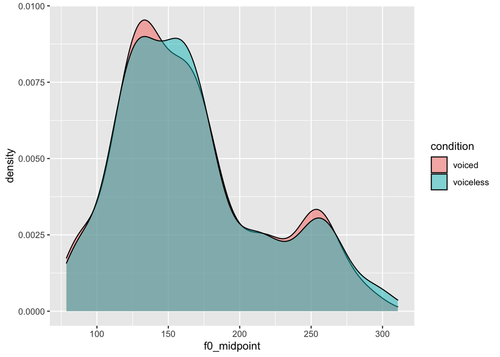

```r
data_e1_1 %>%
  ggplot(
    aes(f0_midpoint, fill = condition)
  ) +
  geom_density(alpha = 0.5)
```

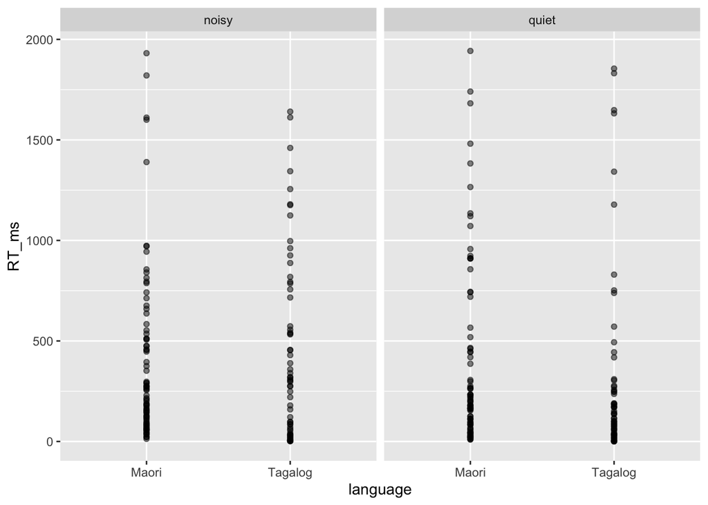

```r
ggsave("plot1.png", dpi = 300)
data_e1_2 <- read_csv("data/data_e1_2.csv")
#language & environment
data_e1_2 %>%
  ggplot(aes(language, RT_ms)) +
  geom_point(alpha = 0.5) +
  geom_smooth(method = "glm",
              aes(colour = environment)) +
  facet_grid(~ environment)
```

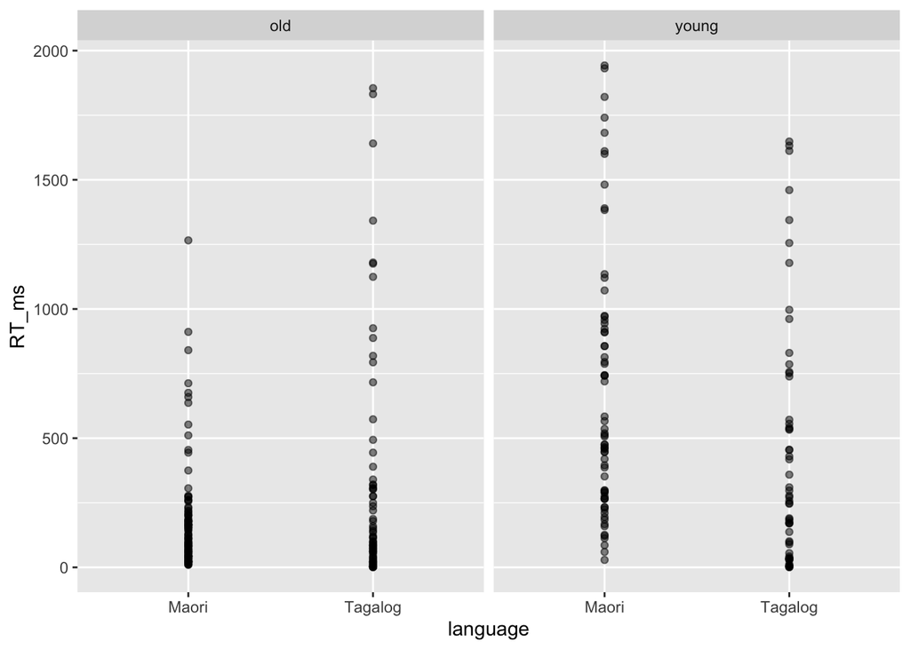

```r
ggsave("plot1_2_1.png", dpi = 300)
#language & age
data_e1_2 %>%
  ggplot(aes(language, RT_ms)) +
  geom_point(alpha = 0.5) +
  geom_smooth(method = "glm",
              aes(colour = age)) +
  facet_grid(~ age)
```

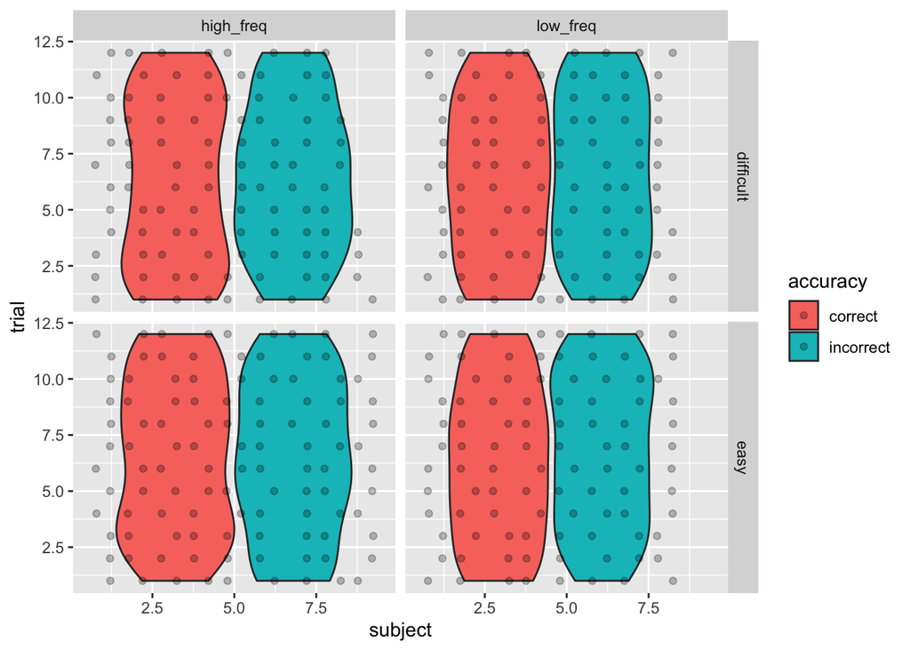

```r
ggsave("plot1_2_2.png", dpi = 300)
data_e1_3 <- read_csv("data/data_e1_3.csv")
data_e1_3 %>%
  ggplot(aes(subject, trial,
             fill = accuracy)) +
  geom_violin() +
  geom_point(
    position = position_jitterdodge(
      jitter.width = 0.05,
      dodge.width = 0.9
    ),
    alpha = 0.25
  ) +
  facet_grid(condition ~ priming)
```

```r
ggsave("plot1_3_1.png", dpi = 300)
```

## Exercise 2

The following plots are not appropriate for the type of data they show.

Briefly describe what is wrong with the plot and write code to create a more appropriate plot (looking at the data frame might help you).

‘geom_bar’ is used to visualize the distribution of a categorical variable, whereas ‘geom_point’ is used to visualize the relationship between two continuous variables.

```r
data_e2_1 <- read_csv("data/data_e2_1.csv")
```

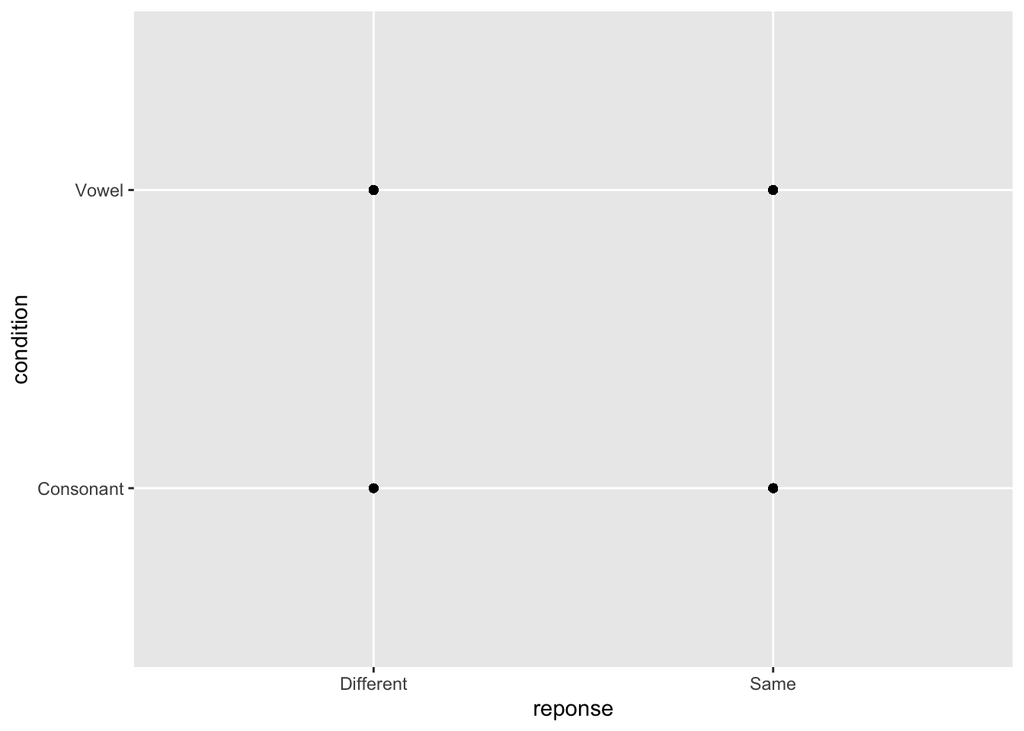

```r
data_e2_1 %>%
  ggplot(aes(reponse, condition)) +
  geom_point()
```

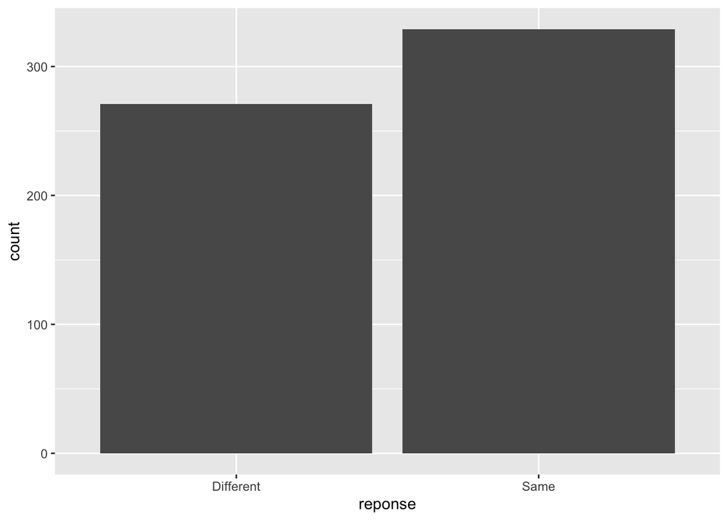

```r
ggsave("plot2_1_1.png", dpi = 300)
data_e2_1 <- read_csv("data/data_e2_1.csv")
data_e2_1 %>%
  ggplot(aes(reponse)) +
  geom_bar()
```

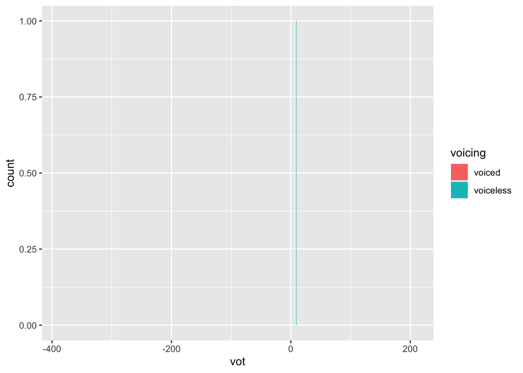

```r
ggsave("plot2_1_2.png", dpi = 300)
data_e2_2 <- read_csv("data/data_e2_2.csv")
data_e2_2 %>%
  ggplot(aes(vot, fill = voicing)) +
  geom_bar()
```

```r
ggsave("plot2_2_1.png", dpi = 300)
```

```r
data_e2_2 <- read_csv("data/data_e2_2.csv")
```

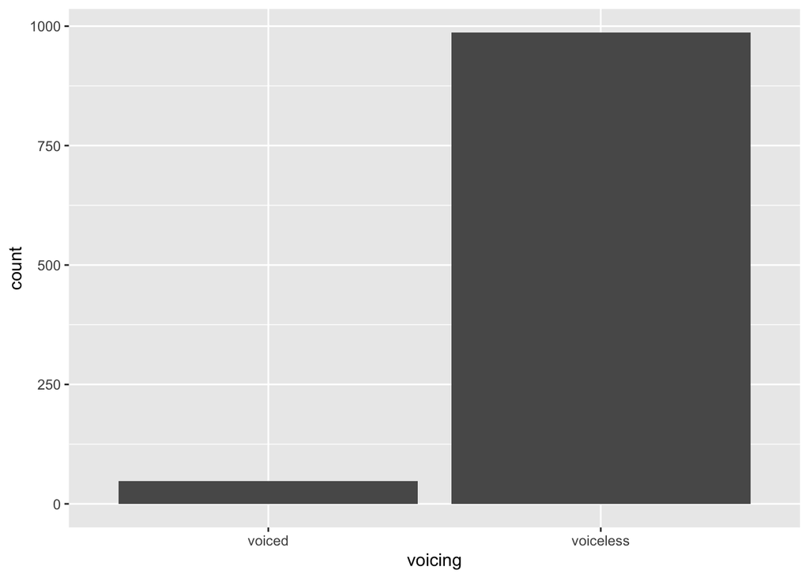

```r
data_e2_2$vot <- as.numeric(data_e2_2$vot)

data_e2_2$voicing <- as.factor(data_e2_2$voicing)

data_e2_2 %>%
  ggplot(aes(voicing, fill = vot)) +
  geom_bar()
```

```r
ggsave("plot2_2_2.png", dpi = 300)
```

## Exercise 3

Read the `ex_3.csv` file in R and obtain summary measures (central tendency: mean, median, or mode; and dispersion: standard deviation or min/max) for each variable in the data. Pick the appropriate measure of central tendency and dispersion for each variable.

```r
ex_3 <- read_csv("data/ex_3.csv")
#to obtain summary measures for each variable
summary(ex_3)
```

```
##      type           response_particle  correct_particle   particle_accuracy
##  Length:6648        Length:6648        Length:6648        Min.   :0.0000
##  Class :character   Class :character   Class :character   1st Qu.:1.0000
##  Mode  :character   Mode  :character   Mode  :character   Median :1.0000
##                                                           Mean   :0.9613
##                                                           3rd Qu.:1.0000
##                                                           Max.   :1.0000
##
##  mean_accuracy        short          critical          exp
##  Min.   :0.8333   Min.   :0.000   Min.   :0.0000   Length:6648
##  1st Qu.:0.9583   1st Qu.:0.000   1st Qu.:0.0000   Class :character
##  Median :1.0000   Median :1.000   Median :1.0000   Mode  :character
##  Mean   :0.9613   Mean   :0.587   Mean   :0.6667
##  3rd Qu.:1.0000   3rd Qu.:1.000   3rd Qu.:1.0000
##  Max.   :1.0000   Max.   :1.000   Max.   :1.0000
##                   NA's   :2287
```

## Exercise 4

Look at the following list of variables:

- Vowel duration.
- Formant values.
- Accuracy.
- Yes/no.
- Reaction times.
- Number of relative clauses.
- Scots vs English.

For each of these variables, specify whether it’s (in principle) distributed according to a Gaussian, Bernoulli/Binomial or Poisson distribution. To to do, create a *vector of strings*, where `"G"` = Gaussian, `"B"` = Bernoulli/Binomial, `"P"` = Poisson. Make sure you list the strings in the order in which the variables appear in the list above.

```r
variables <- c("Vowel duration", "Formant values", "Accuracy", "Yes/no", "Reaction times", "Number of relative clauses", "Scots vs English")

vector_of_strings <- c("G", "G", "B", "B", "G", "P", "B")

data.frame(variables, vector_of_strings)
```

```
##                    variables vector_of_strings
## 1             Vowel duration                 G
## 2             Formant values                 G
## 3                   Accuracy                 B
## 4                     Yes/no                 B
## 5             Reaction times                 G
## 6 Number of relative clauses                 P
## 7           Scots vs English                 B
```

## Exercise 5

Look at the following table that represents the coding of a categorical predictor (assume we use the default alphabetical order). Explain what is wrong with it and write a new table with your solution (you can use https://tablesgenerator.com/markdown_tables# to format the markdown table).

|  | Bangladeshi | Mandarin | English |
| --- | --- | --- | --- |
| Bangladeshi | 1 | 0 | 0 |
| Mandarin | 0 | 2 | 0 |
| English | 0 | 0 | 3 |

The original table is a way of coding a categorical predictor, but it has a problem where all the categories are included. This leads to unreliable results. A corrected table is made by excluding one category, this will give more accurate results.

```r
e5_corrected <- data.frame(Bangladeshi = c(1, 0, 0), Mandarin = c(0, 1, 0))

colnames(e5_corrected) <- c("Bangladeshi", "Mandarin")

rownames(e5_corrected) <- c("Bangladeshi", "Mandarin","English")

e5_corrected
```

```
##             Bangladeshi Mandarin
## Bangladeshi           1        0
## Mandarin              0        1
## English               0        0
```

## Exercise 6

Explain what are the benefits of centring continuous predictors and using sum coding with categorical predictors.

Centering continuous predictors is a way to adjust the data so that it is easier to understand the effects of different predictors on the outcome. Sum coding is a way to simplify categorical predictors so it is easier to understand their effects on the outcome. It also allows for specific comparisons between categories rather than overall comparisons.

## Exercise 7

Imagine you run the following study:

Participants are asked to listen to nonce words and choose whether they think the word refers to a small or a big object. Half of the words are of the `kiki` type (back consonants and high front vowels), while half are of the `baba` type (front consonant and low vowels). The expectation is that `kiki` words should elicit more `small` responses and `baba` words more `big` responses. We also recorder reaction time and we expect shorter reaction times to correlate with a greater effect of hearing a `kiki` word vs a `baba` word.

Read the `data_e7.csv` file. It contains the following columns:

- `subject`: the subject’s ID.
- `response`: whether the subject has chosen `small` or `big`.
- `condition`: `kiki` vs `baba` word.
- `RT`: reaction time in ms.

Make sure to change columns to factors if needed and to specify the order of levels.

```r
data_e7 <- read_csv("data/data_e7.csv")
data_e7$response <- factor(data_e7$response, levels = c("small", "big"))

data_e7$condition <- factor(data_e7$condition, levels = c("kiki", "baba"))
```

Run a linear model that helps you answer the following questions:

1. Do `baba` words elicit more `big` responses than `kiki` words?

It cannot be concluded that ‘baba’ words elicit more ‘big’ responses than ‘kiki’ words based on the model’s summary. The p-value for the interaction term “responsebig:conditionbaba” is 8.96e-16, which is less than the significance level of 0.05. This suggests that the effect of responsebig is not the same across the two conditions (baba and kiki).

2. Is the effect of `baba` words on response greater with shorter reaction times?

Based on the p-value of 1.228207e-25 for the interaction term “RT:responsebig:conditionbaba”, it can be concluded that the effect of ‘baba’ words on response is significantly greater with shorter reaction times.

```r
e7_lm <- lmer(RT ~ response * condition * RT + (condition | subject), data = data_e7)
```

```
## boundary (singular) fit: see help('isSingular')
```

```r
summary(e7_lm)
```

```
## Linear mixed model fit by REML. t-tests use Satterthwaite's method [
## lmerModLmerTest]
## Formula: RT ~ response * condition * RT + (condition | subject)
##    Data: data_e7
##
## REML criterion at convergence: 6463.3
##
## Scaled residuals:
##     Min      1Q  Median      3Q     Max
## -3.2764 -0.0349  0.0000  0.0000  5.9289
##
## Random effects:
##  Groups   Name          Variance Std.Dev. Corr
##  subject  (Intercept)    128.9   11.36
##           conditionbaba  128.9   11.36    -1.00
##  Residual               2792.0   52.84
## Number of obs: 600, groups:  subject, 30
##
## Fixed effects:
##                                Estimate Std. Error         df t value Pr(>|t|)
## (Intercept)                   414.24490    4.04920   41.14581 102.303  < 2e-16
## responsebig                  -413.09929   38.26936  582.86974 -10.795  < 2e-16
## conditionbaba                -414.24490   30.56137  577.41581 -13.555  < 2e-16
## responsebig:conditionbaba     413.09929   49.96217  592.83688   8.268 8.96e-16
## RT:responsebig                  0.99712    0.08675  578.64197  11.494  < 2e-16
## RT:conditionbaba                1.00000    0.02535  564.24186  39.455  < 2e-16
## RT:responsebig:conditionbaba   -0.99712    0.09079  583.95857 -10.982  < 2e-16
##
## (Intercept)                  ***
## responsebig                  ***
## conditionbaba                ***
## responsebig:conditionbaba    ***
## RT:responsebig               ***
## RT:conditionbaba             ***
## RT:responsebig:conditionbaba ***
## ---
## Signif. codes:  0 '***' 0.001 '**' 0.01 '*' 0.05 '.' 0.1 ' ' 1
##
## Correlation of Fixed Effects:
##             (Intr) rspnsb cndtnb rspns: RT:rsp RT:cnd
## responsebig -0.077
## conditionbb -0.132  0.010
## rspnsbg:cnd  0.059 -0.766 -0.609
## RT:respnsbg -0.002 -0.981  0.000  0.752
## RT:condtnbb  0.000  0.000 -0.946  0.579  0.000
## RT:rspnsbg:  0.002  0.938  0.264 -0.899 -0.956 -0.279
## optimizer (nloptwrap) convergence code: 0 (OK)
## boundary (singular) fit: see help('isSingular')
```

```r
p_value <- summary(e7_lm)$coefficients[,"Pr(>|t|)"]["RT:responsebig:conditionbaba"]

p_value
```

```
## RT:responsebig:conditionbaba
##                 1.228207e-25
```

Report the model specification and the results. Also include a plot of the model results.

The model specification is “RT ~ response * condition * RT + (condition | subject)” and the data used is “data_e7”. The fixed effects estimates are as follows:

- (Intercept) 414.24490
- responsebig -413.09929
- conditionbaba -414.24490
- responsebig:conditionbaba 413.09929
- RT:responsebig 0.99712
- RT:conditionbaba 1.00000
- RT:responsebig:conditionbaba -0.99712

```r
e7_lm <- lmer(RT ~ condition * response + ( response | subject ), data = data_e7)
```

```
## boundary (singular) fit: see help('isSingular')
```

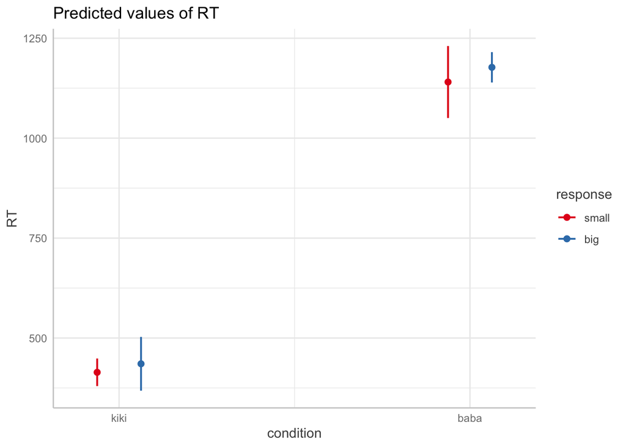

```r
ggpredict(e7_lm, terms = c("condition [all]", "response")) %>% plot()
```

```r
ggsave("plo7_3.png", dpi = 300)
```

## Exercise 8

Imagine you are asked to review a paper. Below you can find the description of a mock study, including the details of the linear model the researchers have run. The results are not included.

> We recorded 50 subjects while they read 100 sentences on a screen. For each subject, half of the sentences were presented together with pictures of natural landscapes. The other half was presented together with pictures of urban landscapes. Background sounds were delivered via headphones to the subject in each trial of the natural and urban setting condition. For each setting (natural vs urban), half of the trials had natural sounds (birds, waterfalls, wind, waves, thunders) and half had urban sounds (traffic noise, sirens, people walking).

> For each trial we measured speech rate as number of syllables per second (syl/s). The hypothesis is that speech rate will be faster in the urban setting trials relative to the natural setting trials. Moreover, the effect of background noise (natural vs urban sounds) will decrease speech rate in the natural setting but not in the urban setting. In other words, we expect the visual setting (natural vs urban) to prime speakers to slow down their speech rate, but we expect the auditory setting (natural vs urban) to make a difference only in the visual natural setting.

> To assess these expectations, we ran a linear model using a Gaussian distribution with visual setting (natural vs urban) as the outcome variable. We included the following predictors: speech rate (centred) and auditory setting (natural vs urban). In R syntax: `lm(visual ~ speech_rate_c + auditory)`.

Now criticise the analysis (i.e. explain what is wrong with it) and run a more appropriate linear model to assess the research hypotheses of the study based on the provided data (`data_e8.csv`). Report the model specification and results of your linear model.

The study that is described in the mock research has some issues with the way it analyzes the data. The researchers want to see how different pictures and sounds affect how fast people speak. But the way they set up the analysis is not right for this kind of data. A more appropriate way to analyze the data would be to use a different type of statistical model that is better suited for this type of outcome.

```r
data_e8 <- read_csv("data/data_e8.csv")
e8_lm <- lmer(
  speech_rate ~ setting*sound +
    ( sound | subject ),
  data = data_e8
)
```

```
## boundary (singular) fit: see help('isSingular')
```

```r
summary(e8_lm)
```

```
## Linear mixed model fit by REML. t-tests use Satterthwaite's method [
## lmerModLmerTest]
## Formula: speech_rate ~ setting * sound + (sound | subject)
##    Data: data_e8
##
## REML criterion at convergence: 12181.7
##
## Scaled residuals:
##     Min      1Q  Median      3Q     Max
## -3.2713 -0.6677 -0.0944  0.5708  6.0465
##
## Random effects:
##  Groups   Name             Variance Std.Dev. Corr
##  subject  (Intercept)      0.004747 0.0689
##           soundurban_sound 0.012498 0.1118   -1.00
##  Residual                  0.664156 0.8150
## Number of obs: 5000, groups:  subject, 50
##
## Fixed effects:
##                                     Estimate Std. Error         df t value
## (Intercept)                          4.58063    0.02503  162.28355 183.039
## settingurban_set                    -0.84615    0.03260 4947.00178 -25.957
## soundurban_sound                     0.01285    0.03623  139.36999   0.355
## settingurban_set:soundurban_sound   -1.25387    0.04610 4947.00178 -27.198
##                                   Pr(>|t|)
## (Intercept)                         <2e-16 ***
## settingurban_set                    <2e-16 ***
## soundurban_sound                     0.723
## settingurban_set:soundurban_sound   <2e-16 ***
## ---
## Signif. codes:  0 '***' 0.001 '**' 0.01 '*' 0.05 '.' 0.1 ' ' 1
##
## Correlation of Fixed Effects:
##             (Intr) sttng_ sndrb_
## sttngrbn_st -0.651
## sondrbn_snd -0.756  0.450
## sttngrbn_:_  0.461 -0.707 -0.636
## optimizer (nloptwrap) convergence code: 0 (OK)
## boundary (singular) fit: see help('isSingular')
```

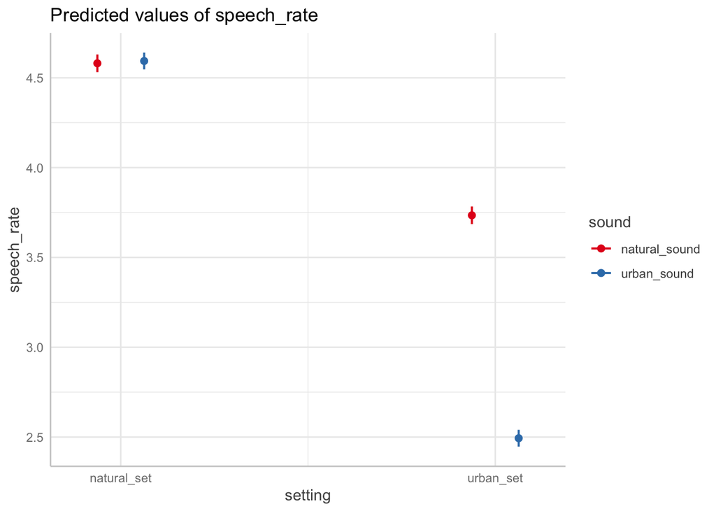

```r
ggpredict(e8_lm, terms = c("setting [all]", "sound")) %>% plot()
```

```r
ggsave("plo8.png", dpi = 300)
```

- (Intercept) 4.58063
- settingurban_set -0.84615
- soundurban_sound 0.01285
- settingurban_set:soundurban_sound -1.25387

## Exercise 9

For each of the following 15 statements, say whether the statement is true or false. To do so, create a *logical vector* with a list of `TRUE` and `FALSE`.

1. A p-value is the probability of the null hypothesis being true.
2. Sum-coding a predictor sets the intercept to the grand mean for that predictor.
3. A significant result is evidence for the alternative hypothesis.
4. A 95% Confidence Interval indicates the probability of having obtained the true mean.
5. The most appropriate distribution family for a dichotomous outcome variable is the Bernoulli family.
6. The ultimate goal of statistics is to assess significance using p-values.
7. Strip charts are appropriate to visualise the individual observations of a continuous variable.
8. Variables included as random effects in a linear model cannot also be included as fixed effects.
9. Linear models assume that the observations in the data are independent.
10. The Student’s *t*-statistic is a standardised measure for the difference between two means.
11. About 68% of the data in a Gaussian distribution is contained within the range marked by mean - 1 SD and mean + 1 SD.
12. The alpha level can only be 0.05.
13. Reproducibility and replicability are the same thing.
14. A study is *robust* when the same results are obtained with the same data but a different analysis.
15. The types of predictor variables in a linear model decide which distribution family to use in the model.

```r
statement <- c(
    "A p-value is the probability of the null hypothesis being true.",
    "Sum-coding a predictor sets the intercept to the grand mean for that predictor.
",
    "A significant result is evidence for the alternative hypothesis.",
    "A 95% Confidence Interval indicates the probability of having obtained the true mean.",
    "The most appropriate distribution family for a dichotomous outcome variable is the Bernoulli family.",
    "The ultimate goal of statistics is to assess significance using p-values.",
    "Strip charts are appropriate to visualise the individual observations of a continuous variable.",
    "Variables included as random effects in a linear model cannot also be included as fixed effects.",
    "Linear models assume that the observations in the data are independent.",
    "The Student's t-statistic is a standardised measure for the difference between two means.",
    "About 68% of the data in a Gaussian distribution is contained within the range marked by mean - 1 SD and mean + 1 SD.",
    "The alpha level can only be 0.05.",
    "Reproducibility and replicability are the same thing.",
    "A study is robust when the same results are obtained with the same data but a different analysis.",
    "The types of predictor variables in a linear model decide which distribution family to use in the model.")

results <- c(FALSE, FALSE, TRUE, FALSE, TRUE, FALSE, TRUE, FALSE, TRUE, FALSE, FALSE, FALSE, FALSE, FALSE, FALSE)

logical_vector <- data.frame(number = 1:15, statement = statement, result = results)

logical_vector
```

```
##    number
## 1       1
## 2       2
## 3       3
## 4       4
## 5       5
## 6       6
## 7       7
## 8       8
## 9       9
## 10     10
## 11     11
## 12     12
## 13     13
## 14     14
```

[output cut: 33 more lines]

# Part II

Part II requires you to conduct a full data analysis of a data set, from reading data to transforming and plotting it, to linear modelling and reporting.

```r
ota2009 <- read_csv("data/ota2009.csv")
#rt1
rt1 <- lm(Words.RT ~ Condition * Item, data = ota2009)
summary(rt1)
```

```
##
## Call:
## lm(formula = Words.RT ~ Condition * Item, data = ota2009)
##
## Residuals:
##    Min     1Q Median     3Q    Max
##  -1939   -885   -526    192  52784
##
## Coefficients:
##                          Estimate Std. Error t value Pr(>|t|)
## (Intercept)             2480.7720   125.7137  19.734  < 2e-16 ***
## ConditionRelated        -407.1216   138.7544  -2.934  0.00336 **
## ConditionUnrelated       311.3572   140.6045   2.214  0.02683 *
## Item                      -1.7597    10.5753  -0.166  0.86785
## ConditionRelated:Item     -0.3247    10.6223  -0.031  0.97561
## ConditionUnrelated:Item   -4.3193    10.6215  -0.407  0.68427
## ---
## Signif. codes:  0 '***' 0.001 '**' 0.01 '*' 0.05 '.' 0.1 ' ' 1
##
## Residual standard error: 2081 on 7532 degrees of freedom
## Multiple R-squared:  0.02047,    Adjusted R-squared:  0.01982
## F-statistic: 31.48 on 5 and 7532 DF,  p-value: < 2.2e-16
```

```r
coef(summary(rt1))[, "Estimate"] / coef(summary(rt1))[, "Std. Error"]
```

```
##             (Intercept)        ConditionRelated      ConditionUnrelated
##             19.73350239             -2.93411612              2.21441756
##                    Item   ConditionRelated:Item ConditionUnrelated:Item
##             -0.16639631             -0.03057118             -0.40665434
```

```r
#rt2
rt2 <- lmer(Words.RT ~ Condition * Item + (Condition | Subject), data = ota2009)
summary(rt2)
```

```
## Linear mixed model fit by REML. t-tests use Satterthwaite's method [
## lmerModLmerTest]
## Formula: Words.RT ~ Condition * Item + (Condition | Subject)
##    Data: ota2009
##
## REML criterion at convergence: 134898.6
##
## Scaled residuals:
##     Min      1Q  Median      3Q     Max
## -2.5901 -0.3353 -0.1310  0.1392 27.6877
##
## Random effects:
##  Groups   Name               Variance Std.Dev. Corr
##  Subject  (Intercept)        1232659  1110.3
##           ConditionRelated     76431   276.5   -0.85
##           ConditionUnrelated   92415   304.0   -0.44  0.70
##  Residual                    3434316  1853.2
## Number of obs: 7538, groups:  Subject, 20
##
## Fixed effects:
##                         Estimate Std. Error       df t value Pr(>|t|)
## (Intercept)             2467.552    272.334   25.087   9.061 2.19e-09 ***
## ConditionRelated        -393.902    138.164  117.732  -2.851  0.00515 **
## ConditionUnrelated       319.628    142.476   98.732   2.243  0.02711 *
## Item                      -0.314      9.418 7478.507  -0.033  0.97341
## ConditionRelated:Item     -1.770      9.460 7478.479  -0.187  0.85155
## ConditionUnrelated:Item   -5.712      9.459 7478.456  -0.604  0.54595
## ---
## Signif. codes:  0 '***' 0.001 '**' 0.01 '*' 0.05 '.' 0.1 ' ' 1
##
## Correlation of Fixed Effects:
##             (Intr) CndtnR CndtnU Item   CndR:I
## ConditnRltd -0.678
## CndtnUnrltd -0.512  0.785
## Item        -0.360  0.709  0.688
## CndtnRltd:I  0.358 -0.735 -0.685 -0.996
## CndtnUnrl:I  0.358 -0.706 -0.712 -0.996  0.991
```

```r
coef(summary(rt2))[, "Estimate"] / coef(summary(rt2))[, "Std. Error"]
```

```
##             (Intercept)        ConditionRelated      ConditionUnrelated
##               9.0607488              -2.8509671               2.2433756
##                    Item   ConditionRelated:Item ConditionUnrelated:Item
##              -0.0333363              -0.1871491              -0.6038631
```

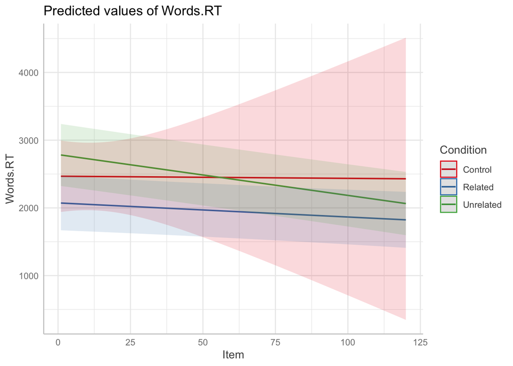

```r
ggpredict(rt2, terms = c("Item [all]", "Condition")) %>% plot()
```

```r
ggsave("plot_rt2.png", dpi = 300)
#rt3
rt3 <- ota2009 %>%
  mutate(Words.ACC = as.numeric(Words.ACC))

rt3_lm <- glmer(Words.ACC ~ Condition * Item + (Condition | Subject), data = rt3, family = binomial())
summary(rt3_lm)
```

```
## Generalized linear mixed model fit by maximum likelihood (Laplace
##   Approximation) [glmerMod]
##  Family: binomial  ( logit )
## Formula: Words.ACC ~ Condition * Item + (Condition | Subject)
##    Data: rt3
##
##      AIC      BIC   logLik deviance df.resid
##   3276.2   3359.3  -1626.1   3252.2     7526
##
## Scaled residuals:
##     Min      1Q  Median      3Q     Max
## -9.5857  0.1578  0.2009  0.2725  0.8184
##
## Random effects:
##  Groups  Name               Variance Std.Dev. Corr
##  Subject (Intercept)        0.4355   0.6599
##          ConditionRelated   0.4133   0.6429   -0.71
##          ConditionUnrelated 0.1481   0.3849   -0.54  0.98
## Number of obs: 7538, groups:  Subject, 20
##
## Fixed effects:
##                           Estimate Std. Error z value Pr(>|z|)
## (Intercept)              3.1012259  0.3309499   9.371  < 2e-16 ***
## ConditionRelated        -0.3788133  0.3541263  -1.070    0.285
## ConditionUnrelated      -1.6040574  0.3220155  -4.981 6.32e-07 ***
## Item                     0.0095306  0.0240687   0.396    0.692
## ConditionRelated:Item   -0.0001109  0.0241983  -0.005    0.996
## ConditionUnrelated:Item  0.0162729  0.0242024   0.672    0.501
## ---
## Signif. codes:  0 '***' 0.001 '**' 0.01 '*' 0.05 '.' 0.1 ' ' 1
##
## Correlation of Fixed Effects:
##             (Intr) CndtnR CndtnU Item   CndR:I
## ConditnRltd -0.875
## CndtnUnrltd -0.888  0.875
## Item        -0.737  0.688  0.757
## CndtnRltd:I  0.733 -0.713 -0.753 -0.995
## CndtnUnrl:I  0.733 -0.685 -0.770 -0.994  0.989
## optimizer (Nelder_Mead) convergence code: 0 (OK)
## Model failed to converge with max|grad| = 0.106127 (tol = 0.002, component 1)
## Model is nearly unidentifiable: very large eigenvalue
##  - Rescale variables?
```

```r
coef(summary(rt3_lm))[, "Estimate"] / coef(summary(rt2))[, "Std. Error"]
```

```
##             (Intercept)        ConditionRelated      ConditionUnrelated
##            0.0113875711           -0.0027417583           -0.0112584138
##                    Item   ConditionRelated:Item ConditionUnrelated:Item
##            0.0010119292           -0.0000117275            0.0017202898
```

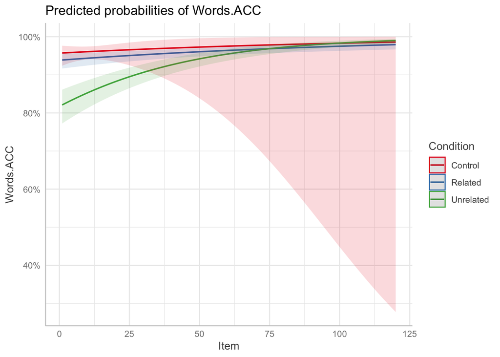

```r
ggpredict(rt3_lm, terms = c("Item [all]", "Condition")) %>% plot()
```

```r
ggsave("plot_rt3_lm.png", dpi = 300)
```

From the output, the estimates, the standard errors, the t-values, p-values, and z-values for the three models:

rt1: * (Intercept): Estimate = 2480.7720, Std. Error = 125.7137, df = 7532, t-value = 19.734, p-value = < 2e-16 *** (significant) * ConditionRelated: Estimate = -407.1216, Std. Error = 138.7544, df = 7532, t-value = -2.934, p-value = 0.00336 ** (significant) * ConditionUnrelated: Estimate = 311.3572, Std. Error = 140.6045, df = 7532, t-value = 2.214, p-value = 0.02683 * (significant) * Item: Estimate = -1.7597, Std. Error = 10.5753, df = 7532, t-value = -0.166, p-value = 0.86785 (not significant) * ConditionRelated:Item: Estimate = -0.3247, Std. Error = 10.6223, df = 7532, t-value = -0.031, p-value = 0.97561 (not significant) * ConditionUnrelated:Item: Estimate = -4.3193, Std. Error = 10.6215, df = 7532, t-value = -0.407, p-value = 0.68427 (not significant)

rt2: * (Intercept): Estimate = 2467.552, Std. Error = 272.334, df = 25.087, t-value = 9.061, p-value = 2.19e-09 *** (significant) * ConditionRelated: Estimate = -393.902, Std. Error = 138.164, df = 117.732, t-value = -2.851, p-value = 0.00515 ** (significant) * ConditionUnrelated: Estimate = 319.628, Std. Error = 142.476, df = 98.732, t-value = 2.243, p-value = 0.02711 * (significant) * Item: Estimate = -0.314, Std. Error = 9.418, df = 7478.507, t-value = -0.033, p-value = 0.97341 (not significant) * ConditionRelated:Item: Estimate = -1.770, Std. Error = 9.460, df = 7478.479, t-value = -0.187, p-value = 0.85155 (not significant) * ConditionUnrelated:Item: Estimate = -5.712, Std. Error = 9.459, df = 7478.456, t-value = -0.604, p-value = 0.54595 (not significant)